# INFSCI 2595 Final Project

Part 2B, Regression - Bayesian Analysis

Zhenyu Li

2022-04-12

```r
library(tidyverse)
theme_set(theme_linedraw())
library(rstanarm)
options(mc.cores = parallel::detectCores())
library(corrplot)
source("./scripts/utils.R")
```

```r
df <- readr::read_csv("./data/final_project_train.csv", col_names = TRUE)
sel_num <- df %>% select_if(is_double) %>% select(!rowid) %>% select(sort(names(.))) %>% colnames()
sel_num_in <- setdiff(sel_num,"response")
sel_cat <- df %>% select(!one_of(sel_num)) %>% select(!rowid) %>% colnames()
sel_cat_in <- setdiff(sel_cat, "outcome")
```

In this section, I will use Bayesian approach to evaluate 3 baseline models with relatively good performance from section 2A.

I have opted to use `rstanarm` for Bayesian analysis.

## Preprocessing

- For regression, the necessary preprocessing steps include:
  - Log-transform the continuous response
  - Normalize the continuous inputs

```r
df_preproc <- df %>%
  mutate_if(is.character,as.factor) %>%
  select(-c(rowid,outcome)) %>%
  mutate(
    response = log(response),
    across(starts_with("x"), scale)
  )
```

## Bayesian Model Fitting

**Select 3 best models from 2A for Bayesian model fitting.**

- Model `mod_2A3` is best model according to BIC, which consist of only linear additive of linear inputs.
- Model `mod_2Ac1` has intermediate AIC/BIC result, by adding some nonlinear features based on `mod_2A3`.
- Model `mod_2Ac3` is best model according to AIC, by adding interaction from `region` to the added nonlinear features from `mod_2Ac1`.
- I will use weak prior of R-squared 0.5.

```r
mod_2A3 <- readr::read_rds("models/mod_2A3")
mod_2Ac1 <- readr::read_rds("models/mod_2Ac1")
mod_2Ac3 <- readr::read_rds("models/mod_2Ac3")
```

**1. Based on model `mod_2A3`, linear additive of all inputs.**

```r
mod_2B1_2A3 <- stan_lm(
  mod_2A3$call$formula,
  data=df_preproc,
  prior = R2(location = 0.5),
  seed = 1324
)
```

**2. Based on model `mod_2Ac1`, where non-linearity is added to some inputs.**

```r
mod_2B2_2Ac1 <- stan_lm(
  mod_2Ac1$call$formula,
  data=df_preproc,
  prior = R2(location = 0.5),
  seed = 1324
)
```

**3. Based on model `mod_2Ac3`, where region interacts with the nonlinear features.**

```r
mod_2B3_2Ac3 <- stan_lm(
  mod_2Ac3$call$formula,
  data=df_preproc,
  prior = R2(location = 0.5),
  seed = 1324
)
```

Save the 3 models to file.

```r
my_models <- mget(ls(pattern = "^mod_2B"))
save_models(my_models)
```

## Conclusions

```r
mod_2B1_2A3 <- readr::read_rds("models/mod_2B1_2A3")
mod_2B2_2Ac1 <- readr::read_rds("models/mod_2B2_2Ac1")
mod_2B3_2Ac3 <- readr::read_rds("models/mod_2B3_2Ac3")
```

### Model Comparison

**Compare models based on information criterion.**

```r
mod_2B1_2A3$waic <- waic(mod_2B1_2A3)
mod_2B2_2Ac1$waic <- waic(mod_2B2_2Ac1)
mod_2B3_2Ac3$waic <- waic(mod_2B3_2Ac3)
my_models <- stanreg_list(
  mod_2B1_2A3, mod_2B2_2Ac1, mod_2B3_2Ac3,
  model_names = c("2B1_2A3, all linear","2B2_2Ac1, add nonlinear","2B3_2Ac3, region: non-linear"))
loo_compare(my_models, criterion = "waic")
```

```
## Model comparison based on WAIC:
##                              elpd_diff se_diff
## 2B3_2Ac3, region: non-linear   0.0       0.0
## 2B2_2Ac1, add nonlinear      -16.8      12.3
## 2B1_2A3, all linear          -32.9      17.0
```

- I choose WAIC for model selection, since at this stage we use training set only for evaluation.
  - Based on WAIC, model `mod_2B3_2Ac3` with interaction from `region` to nonlinear features is the best model.
  - For the other two models, the performance difference are both greater than the respective s.e. on the difference from the best model, confirming the best model selected.

### Examine Best Model

**Analyze the posterior behavior of the best model.**

#### R-squared

```r
bayes_R2(mod_2B3_2Ac3) %>% quantile(c(0.05, 0.5, 0.95))
```

```
##        5%       50%       95%
## 0.6558924 0.6866233 0.7145221
```

- Observation data changed our prior belief about the model uncertainty (R-squared).
  - For R-squared, posterior lower 5th quantile at 0.65, while prior belief was 0.5.

#### Coefficients

**Visualize posterior regression coefficient plot.**

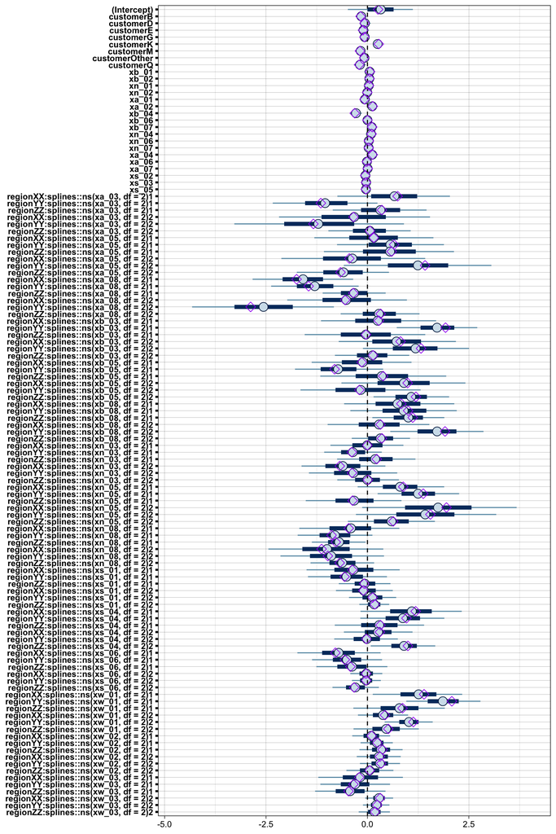

```r
plot(mod_2B3_2Ac3, pars = names(mod_2B3_2Ac3$coefficients)) +
  geom_vline(xintercept = 0, color = "black", linetype = "dashed", size = 0.5) +
  geom_point(
    data = as_tibble(coef(mod_2Ac3), rownames="coef"), aes(x = value, y = coef),
    shape = 5,
    size = 3,
    color = "purple"
  )
```

- The MLE estimated coefficients are plotted using purple diamonds.
- We see the prior slightly constrained the coefficients.

**Visualize the correlation of the posterior coefficients.**

[figure not shown]

```r
mod_2B3_2Ac3 %>% as_tibble() %>%
  select(all_of(names(mod_2B3_2Ac3$coefficients))) %>%
  cor() %>% corrplot(method="color", type="upper")
```

#### Model Uncertainty

**Tasks**

- Study the posterior uncertainty in the noise (residual error), 𝜎.
- How does the `lm()` maximum likelihood estimate (MLE) on 𝜎 relate to the posterior uncertainty on 𝜎 ?
- Do you feel the posterior is precise or are we quite uncertain about 𝜎

**Visualize and compare posterior distribution of σ across 3 models.**

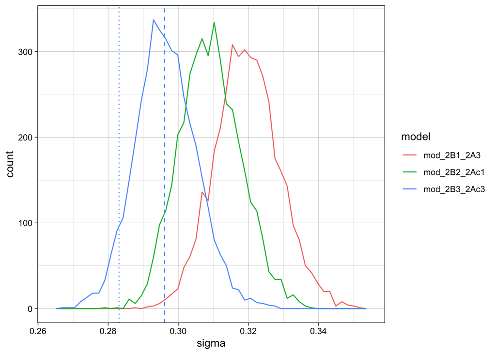

```r
my_models <- mget(ls(pattern = "^mod_2B"))
my_models %>% pull_bayes_posterior_sigma() %>%
  ggplot(aes(x = sigma)) +
  geom_freqpoly(aes(color = model),bins = 50) +
  geom_vline(xintercept = sigma(mod_2Ac3), color="#4D9EFF", linetype="dotted", size=0.5) +
  geom_vline(xintercept = sigma(mod_2B3_2Ac3), color="#4D9EFF", linetype="dashed", size=0.5)
```

**Compute the numbers on the best model.**

```r
sprintf("Posterior mode σ: %.3f", sigma(mod_2B3_2Ac3))
```

```
## [1] "Posterior mode σ: 0.296"
```

```r
sprintf("MLE estimated σ: %.3f", sigma(mod_2Ac3))
```

```
## [1] "MLE estimated σ: 0.283"
```

```r
my_mod_sigma <- mod_2B3_2Ac3 %>% as_tibble() %>% select(sigma)
sprintf("Probability of posterior σ > MLE σ: %.3f%%", mean(my_mod_sigma >= sigma(mod_2Ac3))*100)
```

```
## [1] "Probability of posterior σ > MLE σ: 94.200%"
```

- For the best model identified using WAIC `mod_2B3_2Ac3`:
  - The posterior mode of σ from the Bayesian model is around 0.296 (blue dashed line).
  - The corresponding MLE estimated of σ is 0.283 (blue dotted line).
  - The MLE underestimated σ: there is 94.2% chance σ is greater than the MLE estimate, judging from the posterior samples.
  - Though because the uncertainty interval is small, this does not mean the MLE estimation of σ is too bad.